# Symulacje Komputerowe - Raport

**Autorzy:** *Dworaczyk Marek*, *Czech Piotr* i *Oliwier Arent*

# Spis treści

0. Wprowadzenie
1. Zadanie nr 1: Generator ACORN (Additive Congruential Random Number)  
   1.1. Treść zadania  
   1.2. Rozwiązanie
2. Zadanie nr 2: Generowanie rozkładu normalnego  
   2.1. Treść zadania  
   2.2. Rozwiązanie
3. Zadanie nr 3: Metody redukcji wariancji  
   3.1. Treść zadania  
   3.2. Rozwiązanie
4. Zadanie nr 4: Warunkowa wartość oczekiwana  
   4.1. Treść zadania  
   4.2. Rozwiązanie
5. Zadanie nr 5: Czas ruiny  
   5.1. Treść zadania  
   5.2. Rozwiązanie
6. Zadanie nr 6: Prawa arcusa sinusa  
   6.1. Treść zadania  
   6.2. Rozwiązanie

# Wprowadzenie

Całość naszego projektu podczas rozwiązania wykorzystuje podstawowe pakiety matematyczne, które zaimportujemy:

Dodatkowo w ramach tworzenia i testowania raportu na własnych maszynach / maszynie Czytającego ustawimy stałe ziarno losowości, aby praca zaprezentowana była dla każdego w ten sam sposób

Poniższa linijka wycisza wszystkie ostrzeżenia

# Zadanie 1:

## Treść zadania

Generator ACORN k-tego rzędu oparty jest na ciągach liczbowych zdefiniowanych poprzez równania rekurencyjne:

$$ X_n^0 = X_{n-1}^0, \quad n \geq 1 $$

$$ X_n^m = (X_{n-1}^m + X_n^{m-1}) \mod M, \quad m = 1, \ldots, k, \quad n \geq 1 $$

$$ Y_n^k = \frac{X_n^k}{M}, \quad n \geq 1. $$

## Rozwiązanie

### Implementacja generatora ACORN i porównanie z generatorem NumPy

Generator ACORN k-tego rzędu oparty jest na ciągach liczbowych zdefiniowanych poprzez równania rekurencyjne:

$$ X^0_n = X^0_{n-1}, \quad n \geq 1 $$

$$ X^m_n = (X^{m-1}_n + X^m_{n-1}) \mod M, \quad m = 1, \ldots, k, \quad n \geq 1 $$

$$ Y^k_n = \frac{X^k_n}{M}, \quad n \geq 1 $$

Poniżej znajduje się implementacja tego algorytmu:

```
Czas wykonania funkcji ACORN: 0.00510639 sekundy
Czas wykonania funkcji NumPy: 0.00001448 sekundy
Stosunek czasu (ACORN/NumPy): 352.65
```

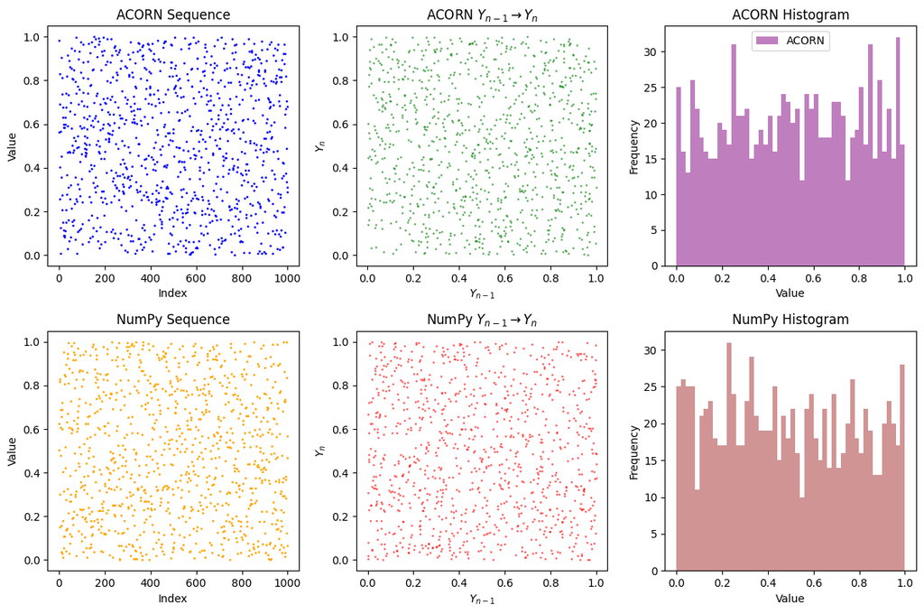

Oba generatory produkują liczby losowe o dobrych właściwościach statystycznych. Na wykresach punktowych dla obu generatorów widoczne jest równomierne rozłożenie punktów, co sugeruje brak wyraźnych wzorców i niezależność generowanych wartości. Histogramy dla obu generatorów również pokazują równomierne rozłożenie wartości w przedziale od 0 do 1, z podobnymi wysokościami słupków, co potwierdza równomierność generacji liczb losowych. Jednakże, pod względem wydajności, generator NumPy jest zdecydowanie szybszy, wykonując generowanie w czasie około 200-400 razy krótszym niż ACORN (podczas testowania na komputerze autora - czas może się różnić w zależności od użytego urządzenia).

Sprawdzimy teraz jak bardzo czas wykonywania się algorytmów różni się w zależności od ilości liczb pseudolosowych do wygenerowania.

**Uwaga:** w tym podpunkcie istotne dla nas było wygnerowanie szczegółowej próbki, dlatego czas jej uruchomienia może być dłuższy - w naszym przypadku dokładniejsze uruchomienie trwa około 6 minut, jeśli jest to za długo zalecamy zmianę tej lini.

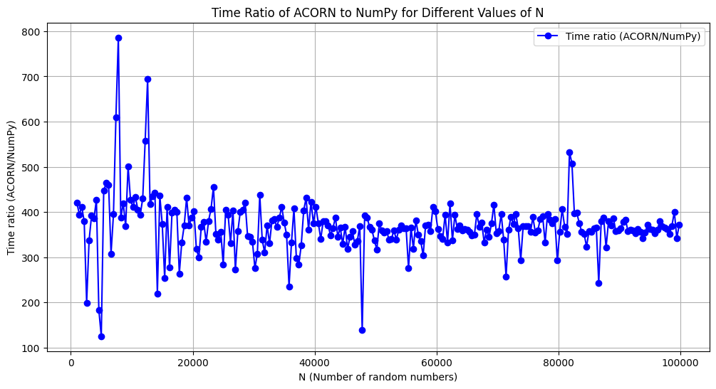

Jak możemy zobaczyć na wykresie dla mniejszych wartości N, iloraz czasu wykonania jest znacznie wyższy i bardziej zmienny. W miarę wzrostu wartości N, stabilizuje się na poziomie około 370 (również mówimy tutaj o teście na komputerze autora) i staje się bardziej przewidywalny. Wskazuje to, że choć ACORN może być wolniejszy dla małych N, jego względna wydajność poprawia się przy większych wartościach.

### Analiza generatora ACORN względem zmiennej Lag

Dla trzech różnych wartości parametru Lag: 10,400,10000 wygenerujemy 1000 liczb pseudolosowych.

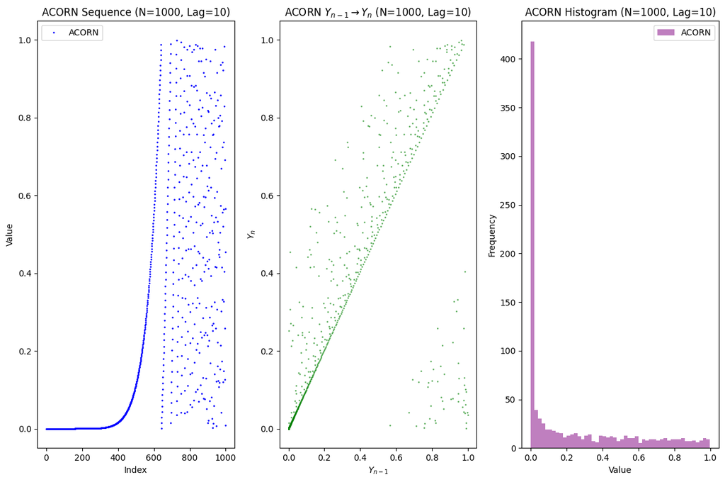

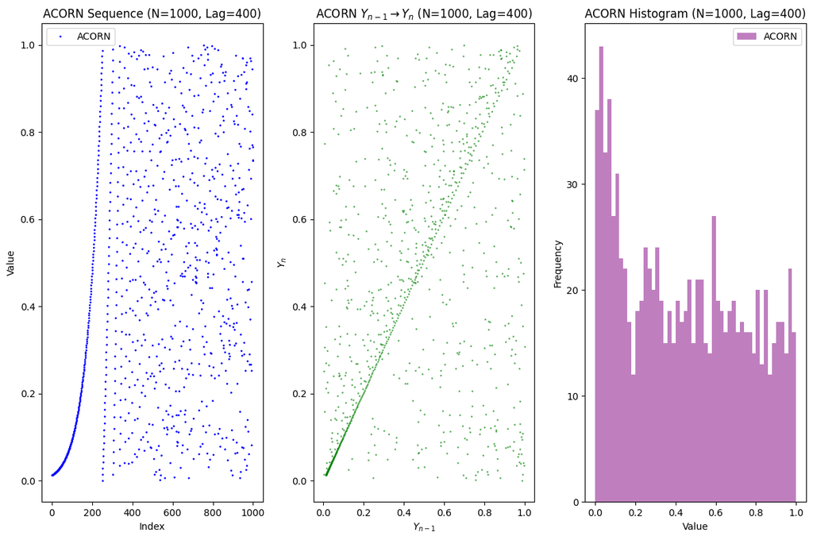

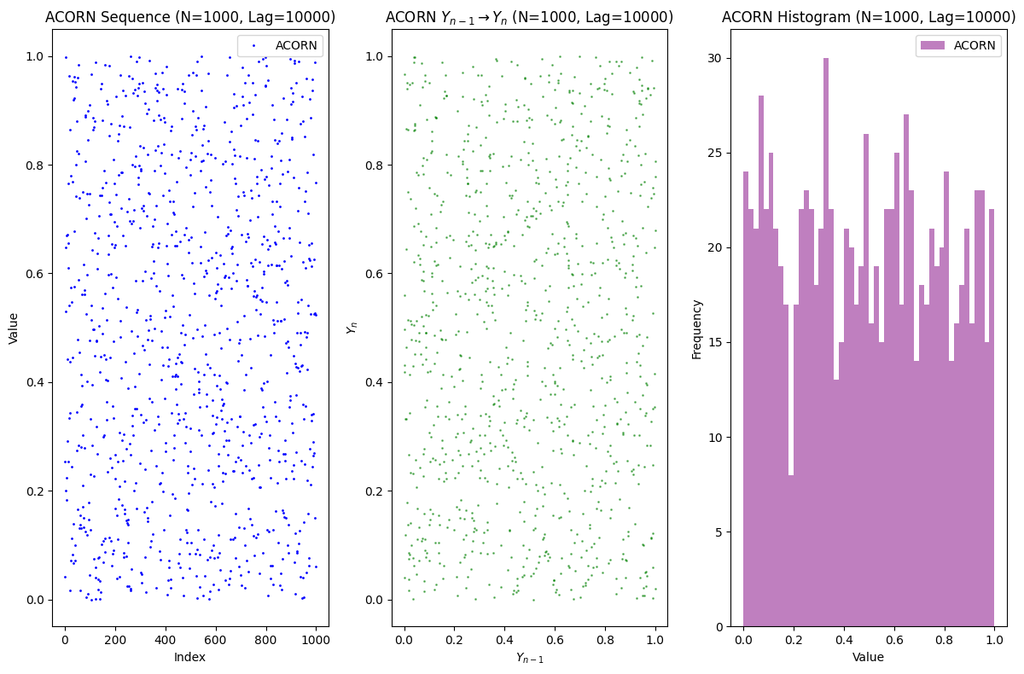

Z analizy wykresów dla różnych wartości parametru Lag wynika, że zwiększanie jego wartości w funkcji ACORN znacząco poprawia losowość generowanych liczb pseudolosowych. Przy niskich wartościach Lag, sekwencje liczb wykazują silną autokorelację, co jest widoczne jako skoncentrowane skupiska wartości oraz liniowe zależności na wykresach $Y_{n-1} \rightarrow Y_n$. W miarę wzrostu Lag, zarówno sekwencje, jak i rozkład liczb stają się bardziej równomierne, a wykresy rozproszenia tracą liniową zależność, co wskazuje na poprawę jakości losowości. Histogramy dla wyższych wartości Lag pokazują bardziej płaski i równomierny rozkład, a nie jak w przypadku histogramu dla Lag = 10, który pokazuje nierównomierny rozkład liczb, z dużą koncentracją wartości blisko 0, co dodatkowo potwierdza, że wyższe wartości Lag prowadzą do lepszej losowości w generowanych liczbach.Wprowadzają większy "odstęp czasowy" między kolejnymi wartościami wykorzystywanymi do generowania nowych liczb pseudolosowych. Dzięki temu każdy nowy numer jest obliczany na podstawie wartości oddalonych od siebie w sekwencji, co zmniejsza korelację między kolejnymi wartościami. W praktyce oznacza to, że każda nowa liczba jest mniej zależna od bezpośrednio poprzednich liczb, co prowadzi do bardziej losowego i mniej przewidywalnego rozkładu.

### Analiza generatora ACORN względem zmiennej seed

Dla trzech różnych wartości parametru seed: 167,99999,123456789 wygenerujemy 1000 liczb pseudolosowych.

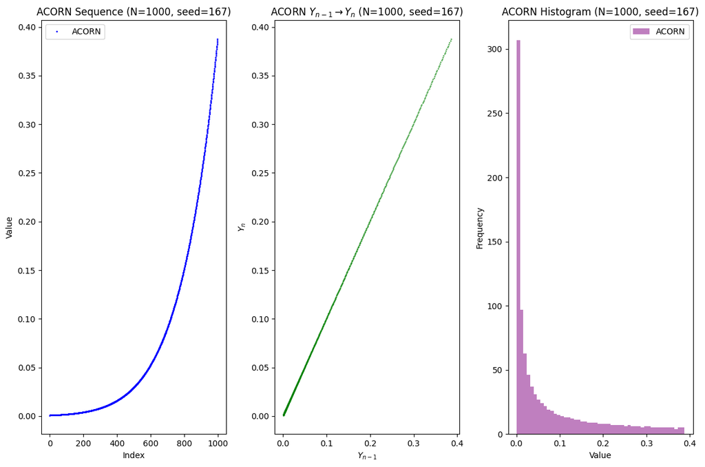

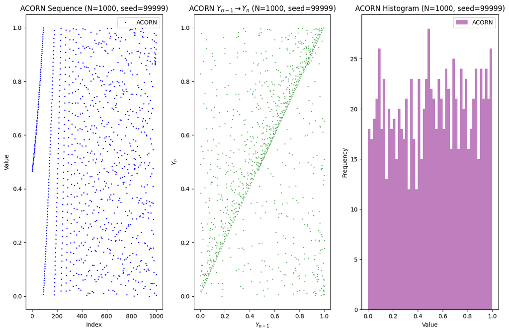

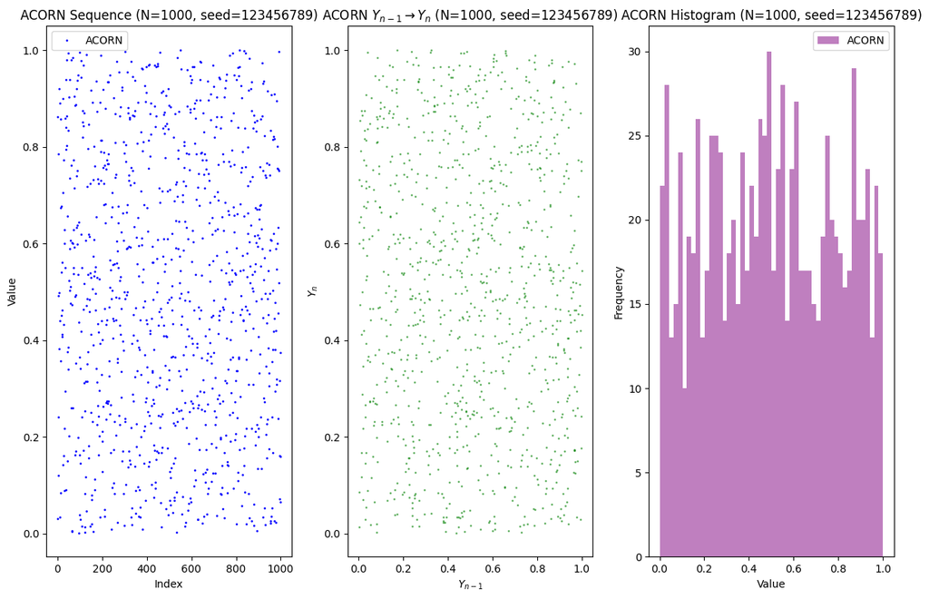

# Zadanie 2:

## Treść zadania

Na listach zadań poznaliśmy kilka metod generowania rozkładu normalnego - nie są to jedyne znane i powszechnie używane metody. W pierwszym kroku sprawdź dotychczas zaimplementowane algorytmy, czy działają poprawnie.

W drugim kroku, zaimplementuj dwie dodatkowe metody generowania rozkładu normalnego:

- metodę "tuzina" przykładowa implementacja w linku poniżej
- metodę zigguratu https://en.wikipedia.org/wiki/Ziggurat_algorithm używając rozkładu wykładniczego. Przetestuj ile razy musimy obliczać funkcję wykładniczą dla różnych wyborów schodków.

Finalnie, porównaj efektywność generowania rozkładu normalnego za pomocą samodzielnie zaimplementowanych metod. Rozważ zarówno czas wykonania algorytmu, jak i dokładność symulacji.

Sprawdź też: https://stat.gov.pl/files/gfx/portalinformacyjny/pl/defaultaktualnosci/5982/7/56/1/ws_07_2019__02_porownanie_generatorow_liczb_pseudolosowych__piotr_sulewski.pdf

## Rozwiązanie

### Ⅰ Implementacja metod generowania rozkładu normalnego poznanych na zajęciach.

#### Metoda stosunku jednostajnych

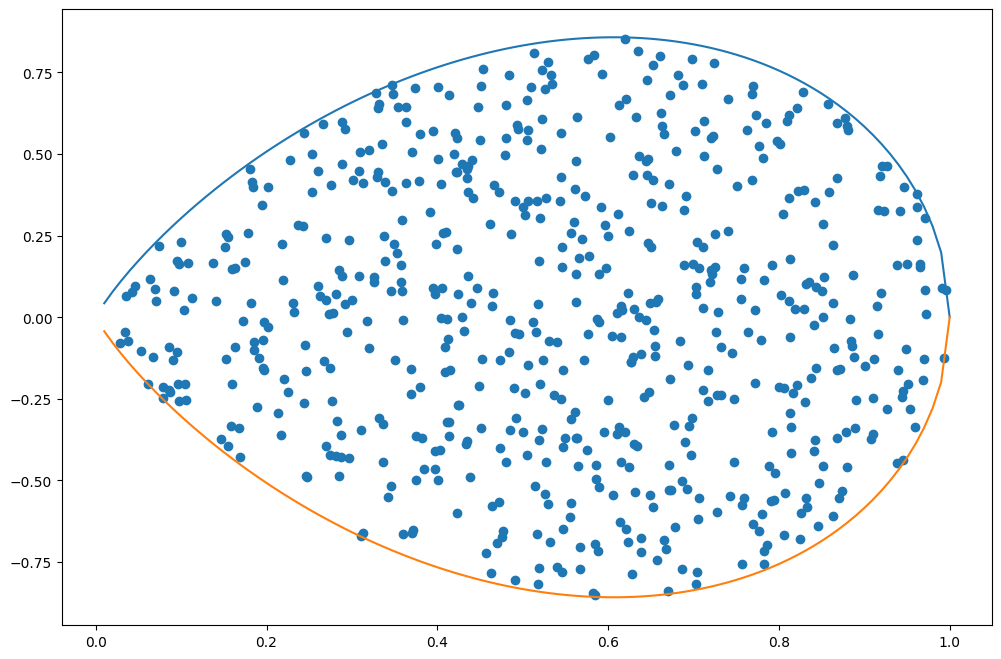

#### Metoda odwrotnej dystrybuanty

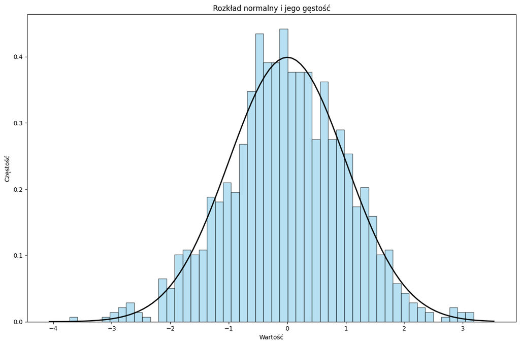

#### Metoda akceptacji-odrzucenia

[figure not shown]

#### Metoda biegunowa generowania rozkładu normalnego w wersji Boxa–Mullera oraz Marsaglii

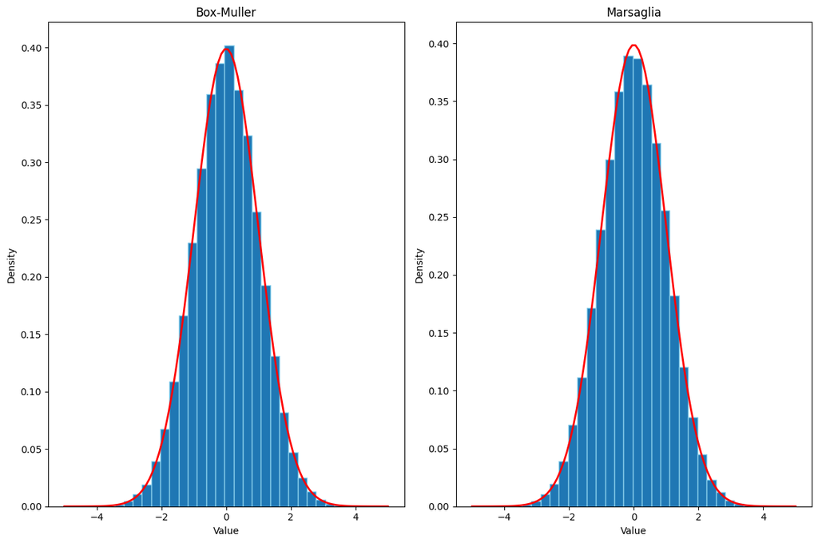

### ⅠⅠ Implementacja metody "tuzina" i "zigguratu" oraz porównanie ich ze sobą.

#### Metoda tuzina

Niech $U_1, U_2, \ldots, U_{12}$ będą liczbami pseudolosowymi $U(0,1)$. Metoda tuzina generująca liczbę pseudolosową $Y$ z $N(m, s)$ jest opisana za pomocą algorytmu:

1. $S = \sum_{i=1}^{12} U_i$
2. $X = S - 6$
3. $Y = sX + m$  
   Poniżej znajduje się implementacja tego algorytmu:

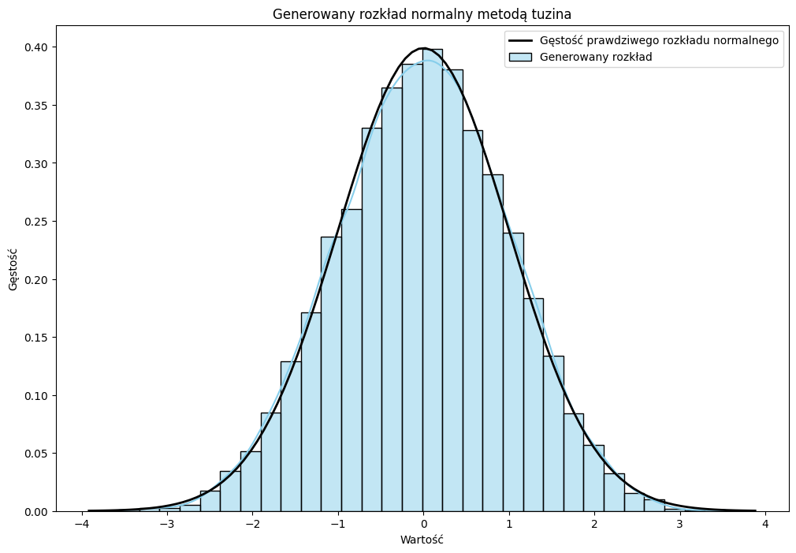

#### Metoda zigguratu

Pełny algorytm zigguratu do generowania rozkładu normalnego używając rozkładu wykładniczego jest następujący:

1. Wybierz losową warstwę $ 0 \leq i < n .$
2. Niech $ x = U_0 x_i .$
3. Jeśli $ x < x_{i+1} $, zwróć $ x .$
4. Jeśli $i = 0$ , wygeneruj punkt z ogona przy użyciu algorytmu zapasowego:
   - Niech $ x = -\ln(U_1) / x_1$.
   - Niech $ y = -\ln(U_2) $.
   - Jeśli $ 2y > x^2 $, zwróć $ x + x_1 $.
   - W przeciwnym razie wróć do kroku 4.
5. Niech $ y = y_i + U_1 (y_{i+1} - y_i)$.
6. Oblicz $ f(x) $. Jeśli $y < f(x) $, zwróć $ x $.
7. W przeciwnym razie wybierz nowe liczby losowe i wróć do kroku 1.

Poniżej znajduje się implementacja tego algorytmu:

```
Rozmiar kroku: 128, Wywołania funkcji wykładniczej: 6490
Rozmiar kroku: 256, Wywołania funkcji wykładniczej: 8208
Rozmiar kroku: 512, Wywołania funkcji wykładniczej: 9106
Rozmiar kroku: 1024, Wywołania funkcji wykładniczej: 9569
```

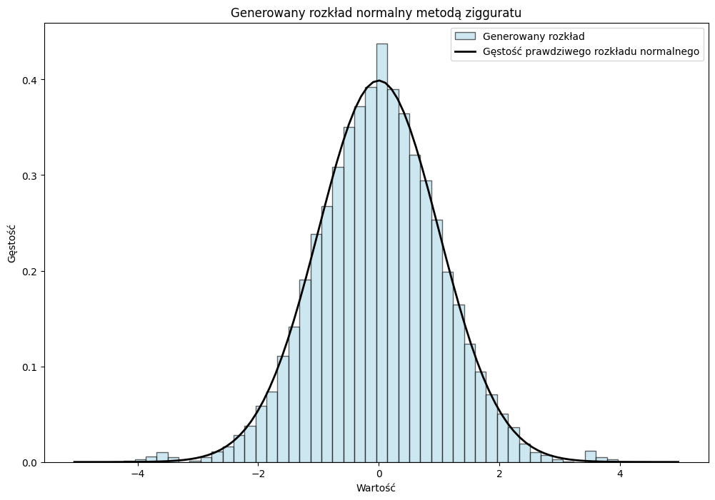

Jak możemy zauważyć wraz ze zwiększaniem rozmiaru kroku w algorytmie zigguratu, liczba wywołań funkcji wykładniczej również rośnie, co wskazuje na większe obciążenie obliczeniowe. Optymalny wybór rozmiaru kroku zależy od kompromisu między precyzją wyników a wydajnością obliczeniową.

Sprawdzimy teraz czas wykonywania obu metod oraz wykersy ich rozkładów

```
Dla n = 1000:
Metoda tuzina - czas wykonania: 0.016990 sekund
Metoda zigguratu - czas wykonania: 0.022985 sekund
Dla n = 10000:
Metoda tuzina - czas wykonania: 0.163900 sekund
Metoda zigguratu - czas wykonania: 0.239851 sekund
Dla n = 100000:
Metoda tuzina - czas wykonania: 1.791899 sekund
Metoda zigguratu - czas wykonania: 2.545951 sekund
Dla n = 1000000:
Metoda tuzina - czas wykonania: 16.882832 sekund
Metoda zigguratu - czas wykonania: 23.806225 sekund
```

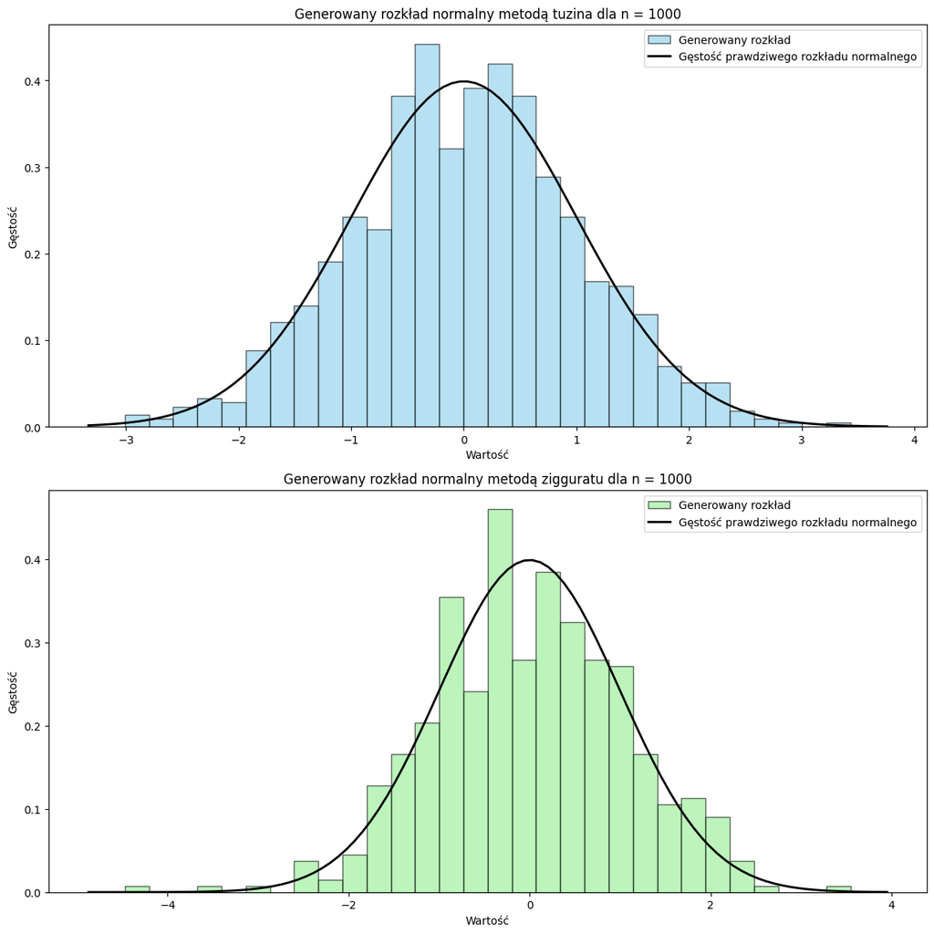

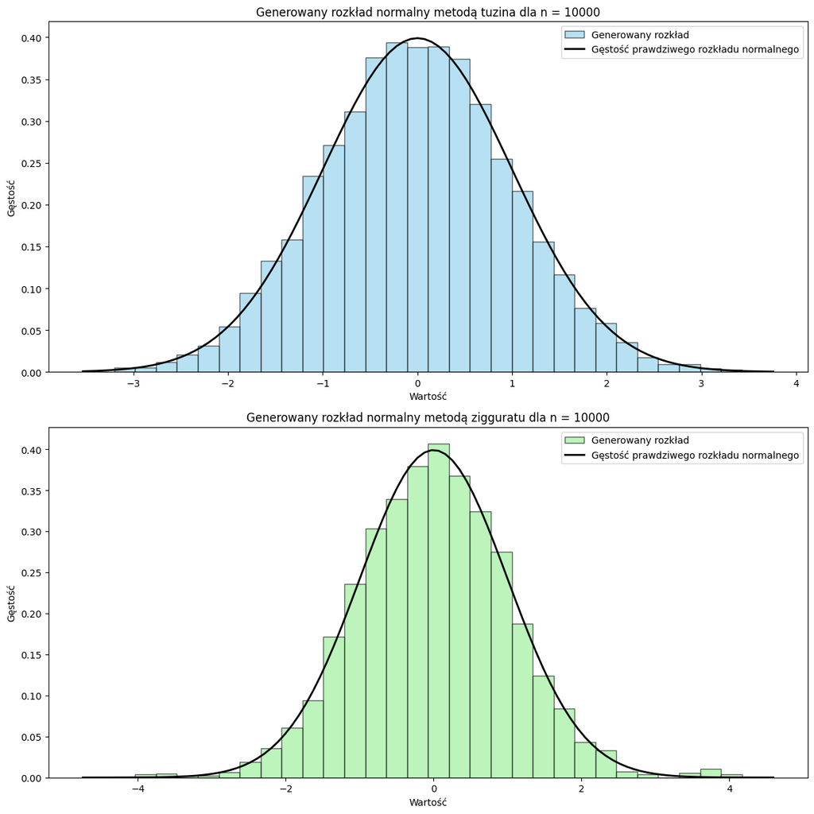

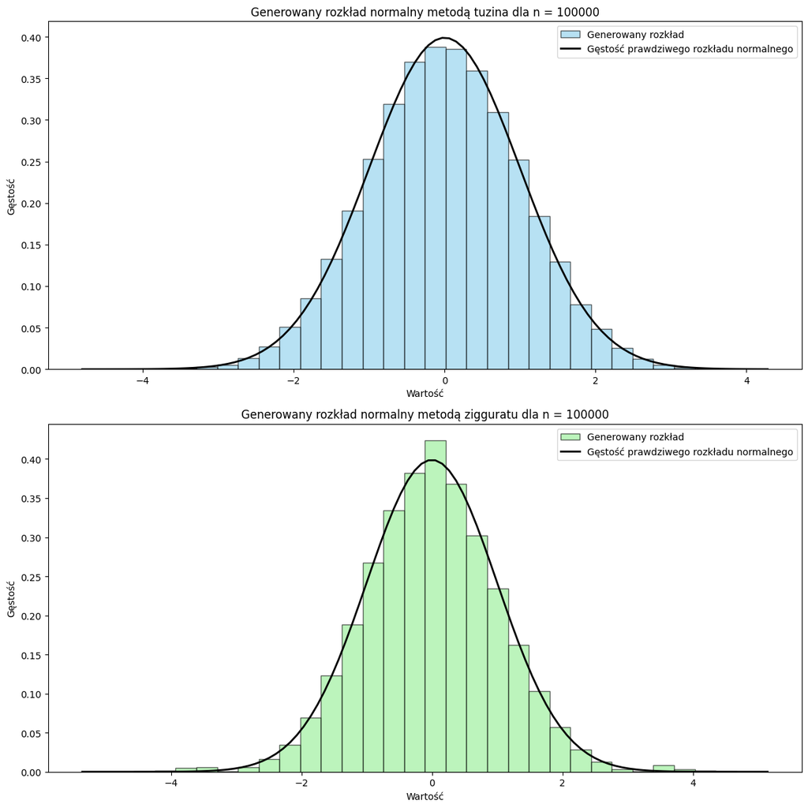

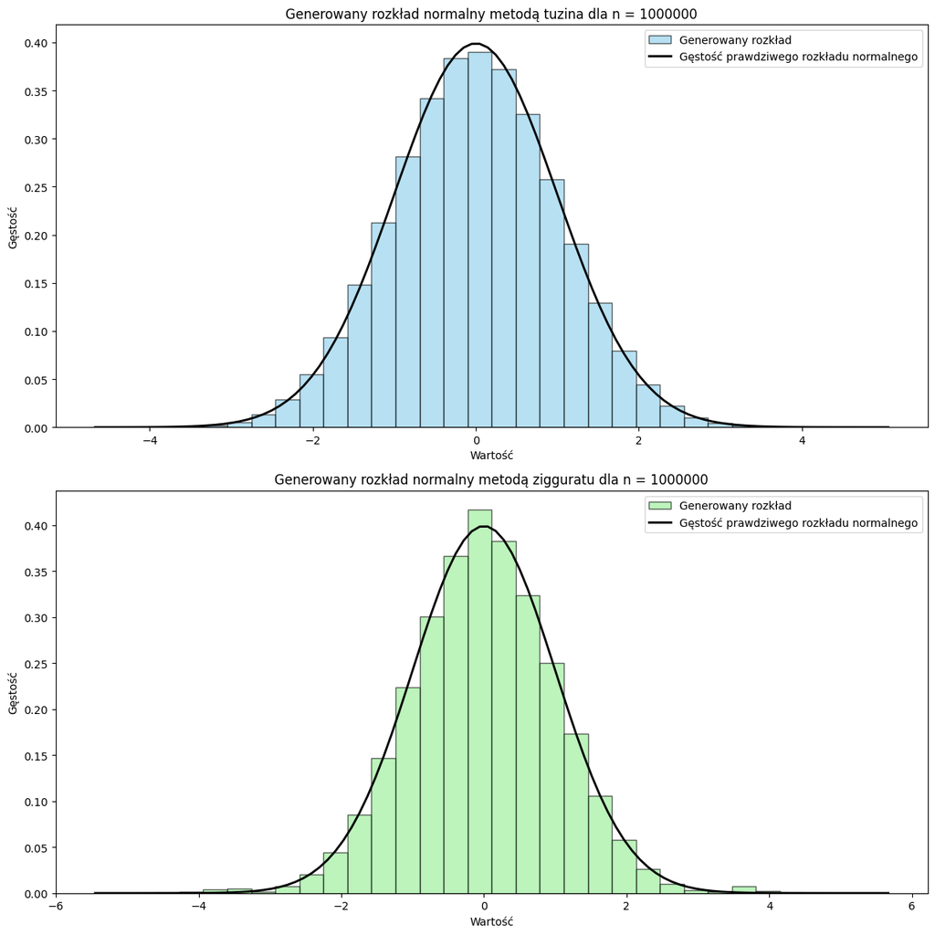

Metoda tuzina jest generalnie szybsza niż metoda zigguratu dla wszystkich badanych liczności próbek (n). Różnica w czasie wykonania staje się bardziej zauważalna wraz ze wzrostem ich liczby. Generowane rozkłady wraz ze wzrostem liczby próbek stają się bardziej dokładne, co szczególnie widać dla liczby próbek równej 1000 i 1000000.

Użyjemy teraz dwóch testów statystycznych: Kołmogorowa-Smirnowa i Shapiro-Wilka, by porównać dokładność generowanych rozkładów metodą "tuzina" i "zigguratu" względem rozkładu normalnego.

W tym bloku kodu definiujemy kluczowe parametry, by testy były wykonywany dokładnie na tym samych próbkach. Warto zwrócić uwagę na parametr `alfa`, który określa poziom istotności testu statystycznego, tutaj ustawiony na 0.05. Jest to standardowa wartość używana w statystyce, oznaczająca 5% ryzyko błędu pierwszego rodzaju. Oznacza to, że istnieje 5% szans na odrzucenie hipotezy zerowej, gdy jest ona prawdziwa. Innymi słowy, jeśli p-wartość uzyskana z testu jest mniejsza niż, hipoteza zerowa zostanie odrzucona na korzyść hipotezy alternatywnej.

#### Test Kołmogorowa-Smirnowa

Test Kołmogorowa-Smirnowa (KS) jest nieparametrycznym testem statystycznym służącym do porównywania dwóch dystrybuant empirycznych lub porównywania jednej dystrybuanty empirycznej z dystrybuantą teoretyczną.

##### Hipotezy

- **Hipoteza zerowa (H0):** Próbki pochodzą z tego samego rozkładu (w przypadku dwóch próbek) lub próbka pochodzi z określonego rozkładu teoretycznego.
- **Hipoteza alternatywna (H1):** Próbki pochodzą z różnych rozkładów lub próbka nie pochodzi z określonego rozkładu teoretycznego.

##### Metodologia

Dla danej próbki oblicza się dystrybuantę empiryczną $F_n(x)$, która jest skumulowaną funkcją rozkładu z próby. Dla drugiej próbki (lub teoretycznego rozkładu) oblicza się odpowiednio $G_m(x)$.

Statystyka testu KS, $D $, jest zdefiniowana jako największa różnica (supremum) między tymi dystrybuantami: $D = \sup_x |F_n(x) - G_m(x)|$

##### Wartość p

Wartość p w teście KS określa prawdopodobieństwo uzyskania statystyki testowej $ D$ o danej wartości (lub bardziej ekstremalnej) pod warunkiem, że hipoteza zerowa jest prawdziwa. Mała wartość p (np. poniżej ustalonego poziomu istotności alfa) sugeruje odrzucenie hipotezy zerowej na rzecz hipotezy alternatywnej.

```
Dla n = 10:
Metoda tuzina - KS statystyka: 0.233387, p-wartość: 0.570471
Metoda zigguratu - KS statystyka: 0.529233, p-wartość: 0.043173
Interpretacja:
Metoda tuzina: Brak podstaw do odrzucenia hipotezy zerowej.Rozkład wygenerowany metodą tuzina jest zgodny z rozkładem normalnym.
Metoda zigguratu: Odrzucenie hipotezy zerowej.Rozkład wygenerowany metodą zigguratu nie jest zgodny z rozkładem normalnym.
---------------------------------------------------------------------------------------------------------------------------
Dla n = 100:
Metoda tuzina - KS statystyka: 0.071547, p-wartość: 0.658568
Metoda zigguratu - KS statystyka: 0.065588, p-wartość: 0.965232
Interpretacja:
Metoda tuzina: Brak podstaw do odrzucenia hipotezy zerowej.Rozkład wygenerowany metodą tuzina jest zgodny z rozkładem normalnym.
Metoda zigguratu: Brak podstaw do odrzucenia hipotezy zerowej.Rozkład wygenerowany metodą zigguratu jest zgodny z rozkładem normalnym.
---------------------------------------------------------------------------------------------------------------------------
Dla n = 1000:
Metoda tuzina - KS statystyka: 0.034247, p-wartość: 0.187051
Metoda zigguratu - KS statystyka: 0.055605, p-wartość: 0.090755
Interpretacja:
Metoda tuzina: Brak podstaw do odrzucenia hipotezy zerowej.Rozkład wygenerowany metodą tuzina jest zgodny z rozkładem normalnym.
Metoda zigguratu: Brak podstaw do odrzucenia hipotezy zerowej.Rozkład wygenerowany metodą zigguratu jest zgodny z rozkładem normalnym.
---------------------------------------------------------------------------------------------------------------------------
Dla n = 10000:
Metoda tuzina - KS statystyka: 0.006496, p-wartość: 0.790031
Metoda zigguratu - KS statystyka: 0.014479, p-wartość: 0.249741
Interpretacja:
Metoda tuzina: Brak podstaw do odrzucenia hipotezy zerowej.Rozkład wygenerowany metodą tuzina jest zgodny z rozkładem normalnym.
Metoda zigguratu: Brak podstaw do odrzucenia hipotezy zerowej.Rozkład wygenerowany metodą zigguratu jest zgodny z rozkładem normalnym.
---------------------------------------------------------------------------------------------------------------------------
Dla n = 100000:
Metoda tuzina - KS statystyka: 0.002828, p-wartość: 0.399823
Metoda zigguratu - KS statystyka: 0.004871, p-wartość: 0.188528
Interpretacja:
Metoda tuzina: Brak podstaw do odrzucenia hipotezy zerowej.Rozkład wygenerowany metodą tuzina jest zgodny z rozkładem normalnym.
Metoda zigguratu: Brak podstaw do odrzucenia hipotezy zerowej.Rozkład wygenerowany metodą zigguratu jest zgodny z rozkładem normalnym.
---------------------------------------------------------------------------------------------------------------------------
```

#### Test Shapiro-Wilka

Test Shapiro-Wilka jest parametrycznym testem statystycznym stosowanym do oceny normalności rozkładu danych. Jest jednym z najbardziej czułych testów do wykrywania odchyleń od normalności, zwłaszcza w przypadku małych próbek.

##### Hipotezy

- **Hipoteza zerowa (H0):** Dane pochodzą z rozkładu normalnego.
- **Hipoteza alternatywna (H1):** Dane nie pochodzą z rozkładu normalnego.

##### Metodologia

Test Shapiro-Wilka opiera się na analizie wartości uporządkowanych w próbie i porównaniu ich z odpowiadającymi im wartościami oczekiwanymi dla próbki z rozkładu normalnego.

Statystyka testu Shapiro-Wilka, $ W $, jest obliczana jako stosunek kwadratu sumy odpowiednio ważonych wartości uporządkowanych do sumy kwadratów odchyleń od średniej: $\large W = \frac{\left( \sum_{i=1}^{n} a_i x_{(i)} \right)^2}{\sum_{i=1}^{n} (x_i - \bar{x})^2}$ Gdzie:

- $ x_{(i)}$ to uporządkowane wartości próbki.
- $ a_i $ to odpowiednie wagi obliczane na podstawie wartości oczekiwanych dla normalnego rozkładu standardowego.
- $\bar{x}$ to średnia arytmetyczna próby.

##### Wartość p

Anaglogicznie jak w pzypadku poprzedniego testu wartość p w teście Shapiro-Wilka określa prawdopodobieństwo uzyskania statystyki testowej $ W$ o danej wartości (lub bardziej ekstremalnej) pod warunkiem, że hipoteza zerowa jest prawdziwa. Mała wartość p (np. poniżej ustalonego poziomu istotności alfa) sugeruje odrzucenie hipotezy zerowej na rzecz hipotezy alternatywnej.

```
Dla n = 10:
Metoda tuzina - Shapiro-Wilk statystyka: 0.986181, p-wartość: 0.989654
Metoda zigguratu - Shapiro-Wilk statystyka: 0.884956, p-wartość: 0.292599
Interpretacja testu Shapiro-Wilka:
Metoda tuzina: Brak podstaw do odrzucenia hipotezy zerowej. Rozkład wygenerowany metodą tuzina jest zgodny z rozkładem normalnym.
Metoda zigguratu: Brak podstaw do odrzucenia hipotezy zerowej. Rozkład wygenerowany metodą zigguratu jest zgodny z rozkładem normalnym.
---------------------------------------------------------------------------------------------------------------------------
Dla n = 100:
Metoda tuzina - Shapiro-Wilk statystyka: 0.988548, p-wartość: 0.549452
Metoda zigguratu - Shapiro-Wilk statystyka: 0.992279, p-wartość: 0.980749
Interpretacja testu Shapiro-Wilka:
Metoda tuzina: Brak podstaw do odrzucenia hipotezy zerowej. Rozkład wygenerowany metodą tuzina jest zgodny z rozkładem normalnym.
Metoda zigguratu: Brak podstaw do odrzucenia hipotezy zerowej. Rozkład wygenerowany metodą zigguratu jest zgodny z rozkładem normalnym.
---------------------------------------------------------------------------------------------------------------------------
Dla n = 1000:
Metoda tuzina - Shapiro-Wilk statystyka: 0.996958, p-wartość: 0.053344
Metoda zigguratu - Shapiro-Wilk statystyka: 0.985662, p-wartość: 0.000087
Interpretacja testu Shapiro-Wilka:
Metoda tuzina: Brak podstaw do odrzucenia hipotezy zerowej. Rozkład wygenerowany metodą tuzina jest zgodny z rozkładem normalnym.
Metoda zigguratu: Odrzucenie hipotezy zerowej. Rozkład wygenerowany metodą zigguratu nie jest zgodny z rozkładem normalnym.
---------------------------------------------------------------------------------------------------------------------------
Dla n = 10000:
Metoda tuzina - Shapiro-Wilk statystyka: 0.999538, p-wartość: 0.012838
Metoda zigguratu - Shapiro-Wilk statystyka: 0.994631, p-wartość: 0.000000
Interpretacja testu Shapiro-Wilka:
Metoda tuzina: Odrzucenie hipotezy zerowej. Rozkład wygenerowany metodą tuzina nie jest zgodny z rozkładem normalnym.
Metoda zigguratu: Odrzucenie hipotezy zerowej. Rozkład wygenerowany metodą zigguratu nie jest zgodny z rozkładem normalnym.
---------------------------------------------------------------------------------------------------------------------------
Dla n = 100000:
Metoda tuzina - Shapiro-Wilk statystyka: 0.999915, p-wartość: 0.003848
Metoda zigguratu - Shapiro-Wilk statystyka: 0.996000, p-wartość: 0.000000
Interpretacja testu Shapiro-Wilka:
Metoda tuzina: Odrzucenie hipotezy zerowej. Rozkład wygenerowany metodą tuzina nie jest zgodny z rozkładem normalnym.
Metoda zigguratu: Odrzucenie hipotezy zerowej. Rozkład wygenerowany metodą zigguratu nie jest zgodny z rozkładem normalnym.
---------------------------------------------------------------------------------------------------------------------------
```

#### Winoski z przeprowadzonych testów statystycznych

Dla dużych próbek (n = 10000 i 100000), test Shapiro-Wilka sugeruje, że zarówno metoda tuzina, jak i zigguratu generują rozkłady, które nie są zgodne z rozkładem normalnym, co prowadzi do odrzucenia hipotezy zerowej. Jest to szczególnie widoczne dla metody zigguratu, która wykazuje niezgodność przy większych próbkach.

Ogólnie rzecz biorąc, metoda tuzina wykazuje większą niezawodność w generowaniu rozkładów normalnych dla mniejszych i średnich próbek. Metoda zigguratu, chociaż skuteczna dla mniejszych próbek, wykazuje ograniczenia przy bardzo dużych próbkach, co podkreśla konieczność dokładnej weryfikacji generowanych rozkładów w bardziej wymagających analizach statystycznych

### Podsumowanie

Biorąc pod uwagę oba kryteria:

- Czas wykonania: Metoda tuzina jest bardziej wydajna i szybsza w generowaniu dużych próbek.
- Dokładność symulacji: Obie metody są porównywalne dla małych próbek. Dla dużych próbek, test Shapiro-Wilka wykazuje pewne ograniczenia obu metod w generowaniu idealnie normalnych rozkładów.

Podsumowując, metoda tuzina okazuje się bardziej efektywna pod względem czasu wykonania, szczególnie dla dużych próbek, podczas gdy obie metody wykazują podobną dokładność dla małych próbek. Przy generowaniu dużych zbiorów danych zaleca się dodatkową weryfikację normalności rozkładów, aby zapewnić dokładność wyników analiz statystycznych.

# Zadanie 3: Metody redukcji wariancji

## Treść zadania

Zapoznaj się z metodami redukcji wariancji w metodach Monte Carlo: https://en.wikipedia.org/wiki/Variance_reduction. W szczególności skupimy się na dwóch metodach:

• metoda odbić lustrzanych https://en.wikipedia.org/wiki/Antithetic_variates

• metoda zmiennej kontrolnej https://en.wikipedia.org/wiki/Control_variates

Krok 1.

Metodą Monte Carlo oblicz całkę $$ \int _0^1 \frac{4}{1+x^2}dx $$ (szacowanie liczby $\pi$)

Krok 2.

Zastostuj jedną z metod redukcji wariancji do ponownego obliczenia zadanej całki.

Krok 3.

Przedstaw analizę błędu względem ilości symulacji w formie tabeli lub wykresu.

## Rozwiązanie

Naszym celem jest przybliżenie liczby $\pi$, poprzez obliczanie całki $$ \int_0^1 \frac{4}{1+x^2} dx, $$ za pomocą metody Monte Carlo. Wykorzystamy dwie metody, dzięki którym zmniejszymy wariancję otrzymywanych wyników. W celu obliczenia tej całki generujemy liczbę $X$ z rozkładu jednostajnego na przedziale $[0,1]$. Następnie liczbę tą wstawiamy w funkcję $f$ zawartą w całce. Proces ten powtarzamy $n$ razy, a naszym wynikiem będzie średnia ze wszystkich pomiarów. W poniższym kodzie definiujemy funkcję podcałkową $f$:

### Metoda zmiennej kontrolnej

Metoda zmiennej kontrolnej polega na wykorzystaniu estymatora cechy, której wartość znamy, w celu zmniejszenia wariancji estymatora cechy, której wartość chcemy przybliżyć. Niech $m$ będzie estymatorem nieznanego wyniku całki $$ \int_0^1 \frac{4}{1+x^2} dx, $$ Jako zmienną kontrolną zdefiniujemy znany nam wynik całki: $$ \int_0^1 1+x^2 dx = \frac{4}{3}, $$ której estymatorem będzie $t$: $$ t = 1+U^2 . $$ Wykorzystując zdefiniowane wyżej wartości stworzymy nowy estymator: $$ m^* = m + c(t-\frac{4}{3}). $$ Wartość oczekiwana tego estymatora jest taka sama jak dla $m$, ponieważ $\mathbb{E}[t] - \mathbb{E}[\frac{4}{3}] = 0$. Z kolei wariancja tego estymatora będzie zależna od $c$. Aby zminimalizować wariancję, c powinno wynosić: $$ c = -\frac{Cov(m,t)}{Var(t)} $$ Podstawiając to pod wzór otrzymujemy nowy estymator o tej samej wartości oczekiwanej lecz zmniejszonej wariancji. Niżej zdefiniowaliśmy funkcje potrzebne do wykorzystania tej metody.

W kolejnym kroku będziemy chcieli przedstawić efektywność naszych metod. Za pomocą każdej z nich wygenerujemy $n$ wartości i zobaczymy czy ich średnia jest równa $\pi$, jaką mają wariancję oraz za pomocą violinplot'a jak bardzo rozległe są wyniki.

```
======================================================================
Metoda Monte Carlo
wartość średnia: 3.1379111626268057, wariancja: 0.4116868936904351
======================================================================
Metoda zmiennej kontrolnej
wartość średnia: 3.143143960579875, wariancja: 0.012562546538806974
======================================================================
Metoda odbić lustrzanych
wartość średnia: 3.1395913149883965, wariancja: 0.003439687252342079
======================================================================
```

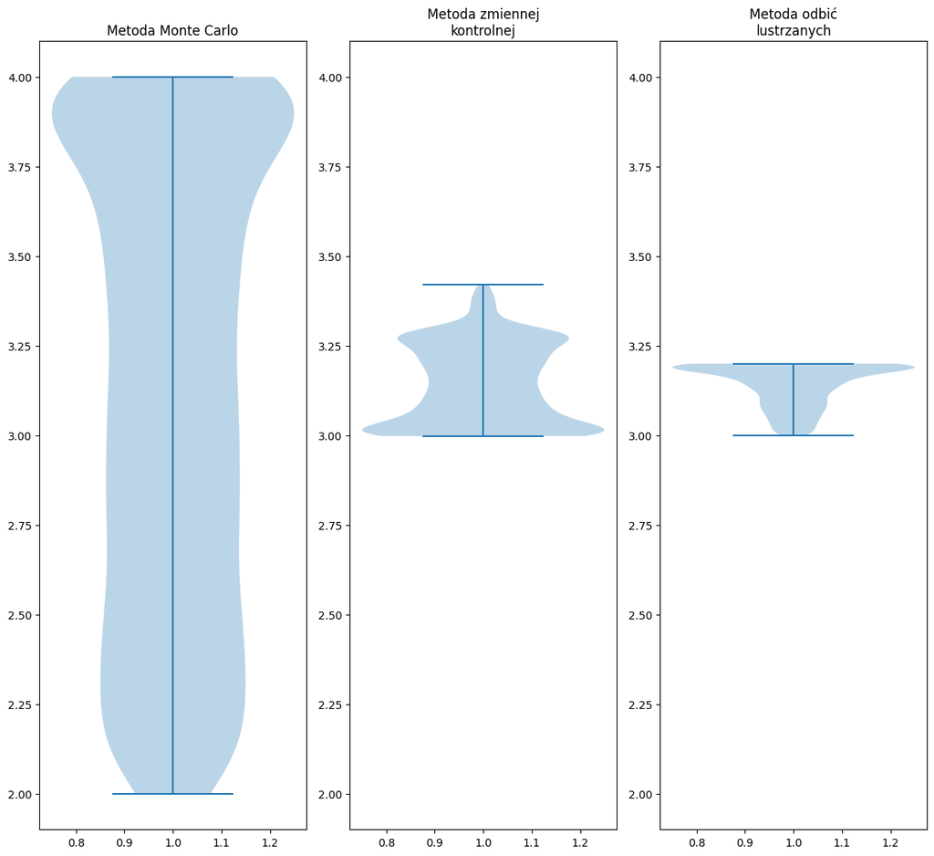

Na powyższym wykresie widać, że obydwie metody zwracając wyniki w dużo mniejszym przedziale niż tradycyjna metoda Monte Carlo. Następnie chcielibyśmy sprawdzić jak bardzo wielkość próby, z której średnią przyjmiemy za wynik, wpływa na jego dokładność. Dlatego dla 100 równo rozłożonych wartości $n$ z przedziału $[1000,100000]$ obliczymy średnią z naszych prób i zobaczymy czy wynik będzie stawał się dokładniejszy.

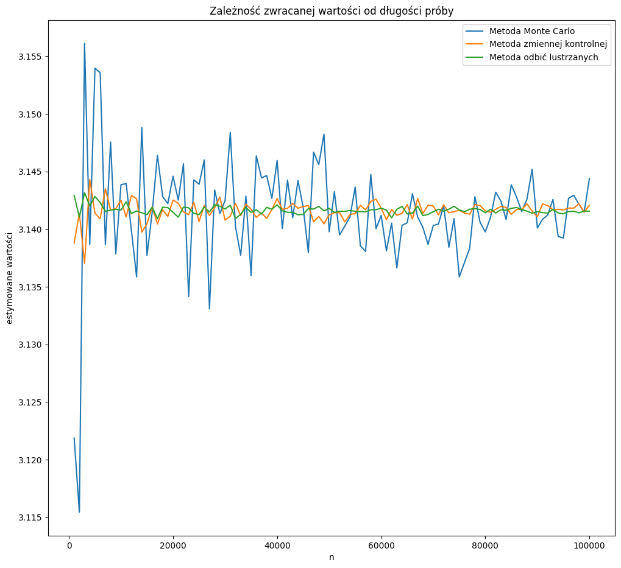

Na tym wykresie widać, że skoki dla metody Monte Carlo są dużo większe dla prób o mniejszych rozmiarach. Wyniki dla metody zmiennej kontrolnej są tylko trochę bardziej rozległe dla mniejszych prób, zaś metoda odbić lustrzanych daje stale dokładne wyniki. Wynika stąd, że najlepiej jest stosować metodę odbić lustrzanych w celu zmniejszenia wariancji przy estymacji wartości metodą Monte Carlo.

# Zadanie 4: Warunkowa wartość oczekiwana

## Treść zadania

Wartość oczekiwana f(X) zmiennej Y warunkowanej zmienną X ma bardzo ciekawą interpretację, mianowicie spełnia własność

$$ E(Y|X\ =\ x)\ =\ f(x)\ =\ \arg \min_g E ((Y - g(X))^2). $$

Oznacza to, że E (Y |X) to najlepsze przybliżenie w sensie $L^2$ zmiennej $Y$ korzystające z danych pochodzących ze zmiennej $X$. Sprawdź symulacyjnie następujące stwierdzenia

- **a.** Jeśli $X$,$Y$ są zmiennymi niezależnymi a $E(Y) = 0$, to dla $Z = XY + \sin X$ zachodzi $E(Z|X) = \sin X$. Jako przykład zaprezentujemy $X$, $Y$ iid ~ $N(0,1)$. Zrób scatterplot $X → E(Z|X)$ wysymulowanych wartości i zaznacz na nim wartości estymowane oraz teoretyczne $E(Z|X)$.
- **b.** Gdy $N$ jest procesem Poissona o intensywnosci $\lambda$, to dla $T \ge t \ge 0$ zachodzi $E(N_t|N_T) = \frac{tN_T}{T}$. Oznacza to, że np. zakładając przybywanie klientów do sklepu zgodnie z procesem Poissona i mając dane na temat dotychczasowej ilości klientów w sklepie w chwili $T$ (czyli $N_T$), to najlepszym przybliżeniem dotychczasowej chwili klientów w chwili $t \lt T$ równej $N_t$ jest $\frac{tN_T}{T}$. Jako przykład możesz wziąć np. $T = 1$, $\lambda = 10$ (zależnie od metody, niekoniecznie potrzebujesz parametru intensywności). Zrób wykres $t → E(N_t|N_T)$ dla kilku możliwych realizacji $N_T$ i zaznacz na nim wartości estymowane.
- **c.** Gdy $N$ jest procesem Poissona o intensywnosci $\lambda$, to dla $t \ge s \ge 0$ zachodzi $E(N_t|F_s) = N_s + \lambda(t −s)$, gdzie $F_s$ to filtracja naturalna procesu $N_s$. Oznacza to, że np. zakładając przybywanie klientów do sklepu zgodnie z procesem Poissona i mając dane na temat dotychczasowej ilości klientów w sklepie w każdej chwili $\omega$ spełniającej $0 \ge ω \ge s$ (czyli $F_s$), to najlepszym przybliżeniem dotychczasowej chwili klientów w chwili $t \ge s$ jest $N_s + \lambda (t−s)$. Jako przykład możesz wziąć np. $s = 1$, $\lambda = 10$. Zrób wykres $t → E(N_t|F_s)$ dla kilku możliwych realizacji $N_s$, $s \ge t$, i zaznacz na nim wartości estymowane. Podpowiedź: Wygeneruj kilka trajektorii $N_\omega$, $\omega \ge s$ i wybierz z nich te, które przybierają różne wartości $N_s$ (w tym kroku nie potrzebowałeś użycia parametru intensywności). Następnie skorzystaj z własności Markowa i dla każdej z wybranych realizacji $N_\omega$, $\omega \ge s$ dosymuluj trajektorie $N_\omega$ dla $s \gt \omega \ge t$, za pomocą których wyestymuj $E(N_t|F_s)$.

## Rozwiązanie

### Ad. a.

Zadanie to rozpoczniemy od wygerowania unikalnych $X$ ~ $N(0,1)$

Przygotowaliśmy sobie zestaw unikalnych parametrów $X$, ponieważ podczas obliczania $E(Z|X)$ to $X$ będzie wartością nam znaną wedle której wygenerujemy zestaw "zetek".

Dlatego teraz przejdziemy przez każdą unikalną wartość $X$ i wygenerujemy dla niej $M$ razy wartość $Z|X$.

Wyświetlmy dane, które udało nam się uzyskać

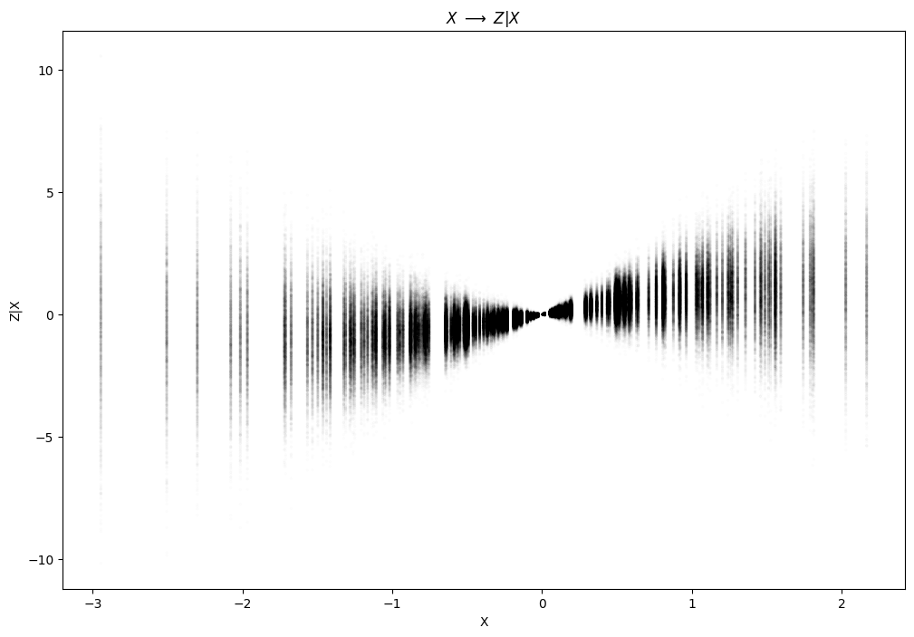

Na tak przygotowanej "chmurze" danych chcielibyśmy zweryfikować empirycznie podaną własnosć, dla tego konkretnego przypadku $E(Z|X) = \sin X$.

Przygotujmy najpierw empirycznie obliczone wartości $E(Z|X)$ używając średniej jako estymatora.

I tak obliczony zestaw danych porównajmy na wykresie wraz z wskazanym rozwiązaniem teoretycznym

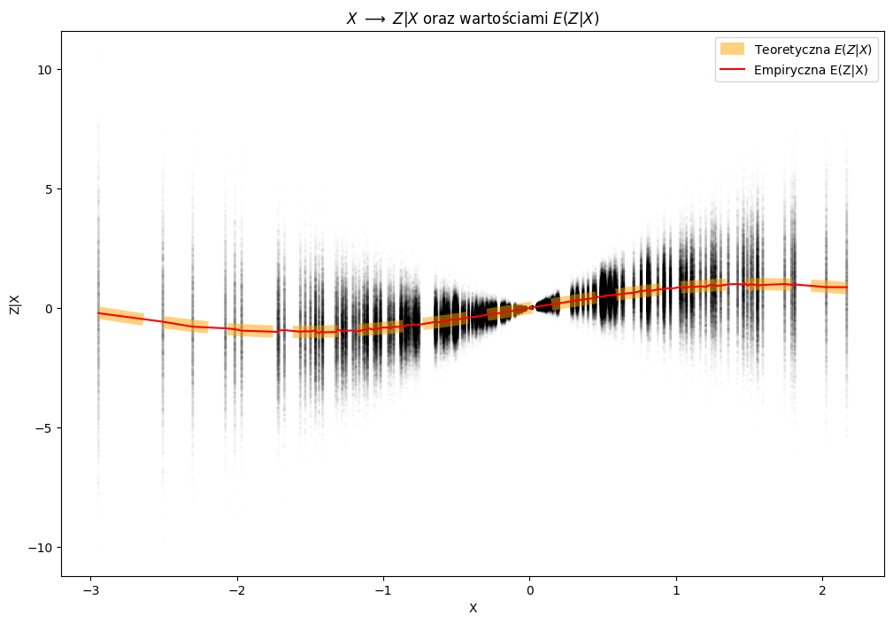

### Ad. b

#### Proces poissona

Implementacje tego zadania rozpoczniemy od przygotowania funkcji do generowania procesu poisonna. W celi uzyskania zestawu $N_t$ wykorzystamy algorytm:

1. Wygeneruj $k \sim Pois(\lambda t)$.
2. $N_t = U \cdot T$, gdzie $U$ to wektor $n$ elementowy $\sim U([0, 1]) \cdot T$
3. Posortuj $N_t$ rosnąco.

**Uwaga!** Zauważmy tutaj, że zgodnie z treścią naszego zadania znana jest nam aktualna liczba klientów $N_T$ - w takim razie każdy generowany przez nas proces Poissona powinien mieć $k = N_T$, zatem możemy uprościć nasz algorytm:

1. Weź $k = N_T$.
2. $N_t = U \cdot T$, gdzie $U$ to wektor $n$ elementowy $\sim U([0, 1]) \cdot T$
3. Posortuj $N_t$ rosnąco.

Następnie, żeby zrealizować zadanie musimy ustawić podstawowe dane algorytmu. Dzięki implementacji generowania procesu Poissona bez wykorzystania parametru $\lambda$ nie musimy go przechowywać w naszym kodzie.

Przy okazji inicjalizacji zadania i definiowania funkcji generującej proces Poissona - zdefiniujemy funkcję pomocniczą do tworzenia ładnych wykresów procesu Poissona

Naszym aktualnym zadanie pozostaje wygenerowanie z pomocą metody Monte Carlo wielu procesów Poissona, których $k = N_T$. Tak stworzone procesy zapiszemy w formie 2 wymiarowej tablicy `czas x ilość_klientów`, aby w późniejszych krokach wygodnie obliczyć wartości estymowane $E(N_t|N_T)$. Całość zaimplementujemy w następujący sposób:

Schemat zapisu zmiennaej clients_over_time_per_simulation

| Czas (t) | 0 | 0.1 | 0.2 | ... |
| --- | --- | --- | --- | --- |
| Suma klientów (nr sym 1.) | 0 | 0 | 1 | ... |
| Suma klientów (nr sym 2.) | 1 | 2 | 3 | ... |
| Suma klientów (nr sym ...) | 0 | 1 | 2 | ... |

Z tak przygotowanymi danymi możemy obliczyć estymowaną wartość $E(N_T|N_t)$:

Obliczanie estymowanej wartości

| Czas (t) | 0 | 0.1 | 0.2 | ... |
| --- | --- | --- | --- | --- |
| Suma klientów (nr sym 1.) | 0 | 0 | 1 | ... |
| Suma klientów (nr sym 2.) | 1 | 2 | 3 | ... |
| Suma klientów (nr sym 3.) | 0 | 1 | 2 | ... |
| Wartość estymowana (średnia) | 1/3 | 3/3 | 6/3 | ... |

Wygenerujemy zatem zestaw danych przy użyciu posiadanych funkcji

i przedstawimy je na wykresie (dla wzrokowców dodajemy parę półprzeźroczystych procesów Poissona, które są generowane podczas metody Monte Carlo w celu lepszego zrozumienia, co dzieje się pod powierzchnią:) )

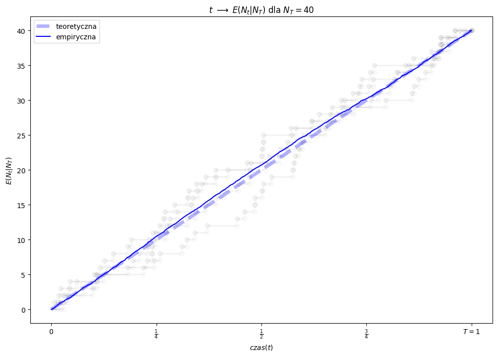

Porównajmy rozwiązanie tego zadania dla paru różnych parametrów $N_T$.

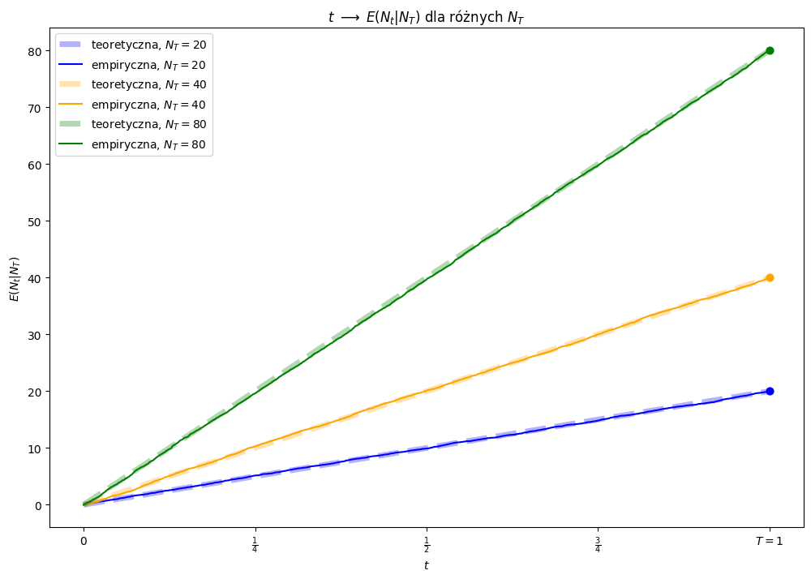

### Ad c.

Zadanie na wstępie może wydawać się bardzo podobne, natomiast całkowicie zmienia się tutaj punkt realizacji. W poprzednim podpunkcie skupialiśmy się na tym, że znaliśmy liczbę klientów tylko w danej, aktualnej, chwili - teraz natomiast znamy całkowity ruch klientów w przeszłości - a nasze zadanie to wysumulowanie przyszłych zmian w tym ruchu

Wynika z tego, że w tym zadaniu będziemy chcieli mieć możliwość generowania procesu Poissona nie tylko od punktu $(0, 0)$, zatem zajmijmy się rozwojem funkcji `get_poisson`

Następnie ustawmy podstawowe parametry oraz wygenerujmy zmianę klientów w przeszłości ($F_s$) - to jest nam znane.

Gdy posiadamy te dane możemy przystąpić do generowania procesów Poissona zmian klientów od chwili, w której się aktualnie znajdujemy uwzględniając znajomość przeszłości.

W tym momencie wygenerowaliśmy sobie procesy dotyczące przyszłości - pozostaje obliczyć ich wartości oczekiwane, tak jak w podpunkcie **b.**

I wyświetlić je na wykresie!

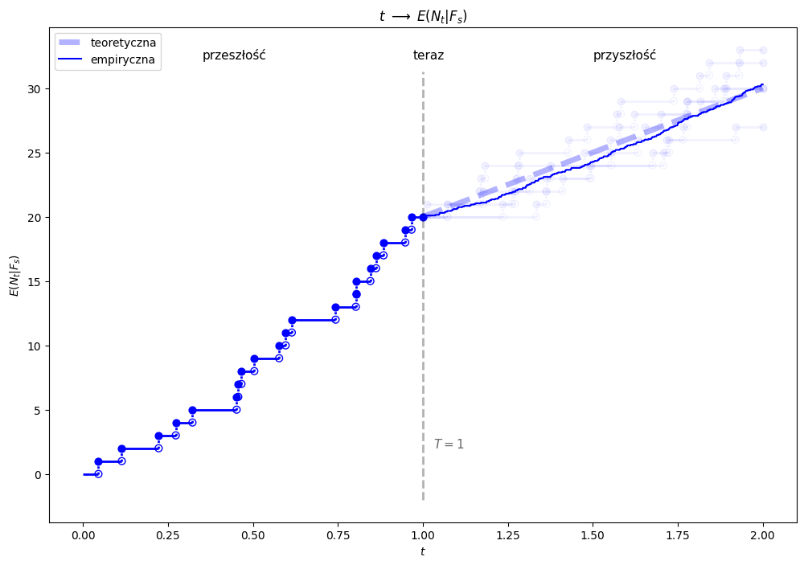

I jak widać na wykresie, przybliżenie teoretyczne jest bardzo bliskie empirycznemu. Odbieganie, które widać na wykresie wyniki z małej ilości dokonanej symulacji, natomiast postanowiliśmy takie pozostawić, aby odbiorca tego sprawozdania widział zbieganie tych wartosci do siebie, a nie od razu jednolite pokrycie.

Przedstawimy jeszcze 2 inne symulacje dla różnych wartości $N_s$ dla których również zwiększymy precyzję.

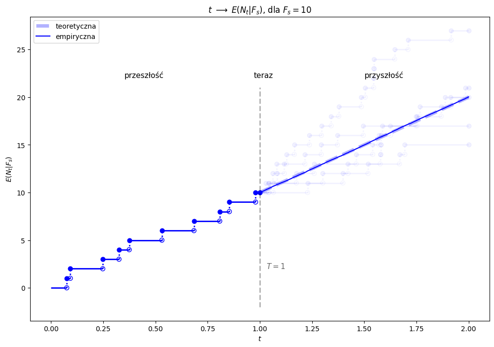

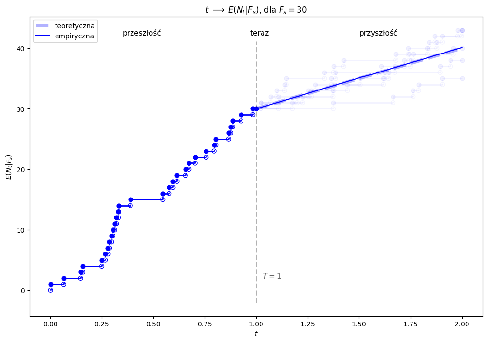

Wykresy dla różnych parametrów dalej się pokrywają, a co więcej zgodnie z założeniem zwiększenie ilości symulacji nałożyło na siebie estymacje empiryczną z wartościami teoretycznymi.

# Zadanie 5: Czas ruiny

## Treść zadania

Niech $X_t$ będzie procesem ruiny modelu Craméra-Lundberga $$ X_t = u + ct - \sum ^{N_t}_{i=0}ξ_i $$ gdzie $t,c,u ≥ 0$, $ξi ∼ Exp(η),$ $ξi ⊥ ξj$ dla $i \ne j$, E (ξi) = η, a $N_t$ jest procesem Poissona o intensywności λ. Czasem ruiny klasycznej nazywamy zmienną $τ = inf\{t > 0|X_t < 0\}$. Prawdopodobieństwem ruiny w czasie nieskończonym nazywamy funkcję $ψ(u,c) = P (τ < ∞)$. Wzór Pollaczka-Chinczyna mówi, że $$ \psi(u,c) = \frac{\eta \lambda}{c}e^{-(\frac{1}{\eta} - \frac{\lambda}{c})u}. $$ Zweryfikuj symulacyjnie ten wynik. W tym celu skorzystaj z pomocniczego prawdopodobieństwa ruiny w czasie skończonym $T$, tj. $Ψ(u,c,T) = P (τ < T)$, $T > 0$, dla odpowiednio dużego $T$. Sporządź wykresy funkcji $u → ψ(u,c_0)$ dla ustalonych $c_0$ oraz $c →ψ(u_0,c)$ dla ustalonych $u_0$ (kilka trajektorii na jednym wykresie) i porównaj je z wartościami wyestymowanymi. Powtórz analizę dla funkcji odwrotnej $$ c(u,\psi) = \frac{\lambda u}{W_0(\frac{u \psi e^{\frac{u}{\eta}}}{\eta})}, $$ gdzie $W_0$ to gałąź funkcji $W$ Lamberta zdefiniowana poprzez równanie $W_0(xe^x) = x$ dla $x ≥0$ (scipy.special.lambertw). Ta analiza odpowiada szukaniu wymaganej wartości wpłat przy danym kapitale początkowym w celu osiągnięcia wymaganego prawdopodobieństwa ruiny. Zweryfikuj symulacyjnie ten wynik. Tym razem sporządź wykresy funkcji $u →c(u,ψ_0)$ dla ustalonych $ψ_0$ (kilka trajektorii na jednym wykresie) i porównaj je z wartościami wyestymowanymi. Pamiętaj, że gdy $c ≤λη$ to zachodzi $ψ = 1$!

## Czas ruiny

Badamy proces ruiny modelu Craméra-Lundberga oznaczonego wzorem: $$ X_t = u + ct − \sum _{i=0}^{N_t} ξ_i, $$ gdzie

- $u$ to kapitał początkowy
- $c$ to stała przyrostu
- $N_t$ to process Poissona o parametrze $\lambda$ wyznaczający czasu kolejnych szkód
- ξ to zmienna losowa o rozkładzie wykładniczym z parametrem $\eta$ wyznaczająca wielkość kosztów szkód

Będziemy chcieli zweryfikować wzór Pollaczka-Chinczyna na prawdopodobieństwo zajścia ruiny modelu w czasie nieskończonym: $$ ψ(u, c) =\frac{ηλ}{c} e^{−(\frac{1}{η} − \frac{\lambda}{c})u}, $$ W tym celu przeprowadzimy symulację modelu Craméra-Lundberga w pewnym skończonym czasie $T$. Następnie za pomocą metody Monte Carlo wyznaczymy prawdopodobieństwa zajścia ruiny przy pewnych parametrach. Te wyniki porównamy z wynikami wzoru Pollaczka-Chinczyna. Zdefiniujmy potrzebne funkcje:

Aby sprawdzić wyniki otrzymane za pomocą wzoru Pollaczka-Chinczyka przeprowadzimy symulację procesu ruiny w czasie skończonym oraz naniesiemy na scatterplot otrzymane prawdopodobieństwa. Zdefiniujemy dwie funkcje wykonujące te działania odpowiednio dla stałych wartości $c$ oraz stałych wartości $u$.

W pierwszej kolejności zbadamy zachowanie się prawdopodobieństwa przy stałych wartościach przyrostu oraz różnych kapitałach początkowych. Wezmiemy $c=\{2,2.5,3\}$ oraz $u$ będące 100-elementowym wektorem liczb z przedziału $[1,10]$. Przy tych oraz przyszłych symulacjach horyzont czasowy będzie wynosił $T=10$, a parametrami rozkładów będą $\lambda = 1$ oraz $\eta = 1$

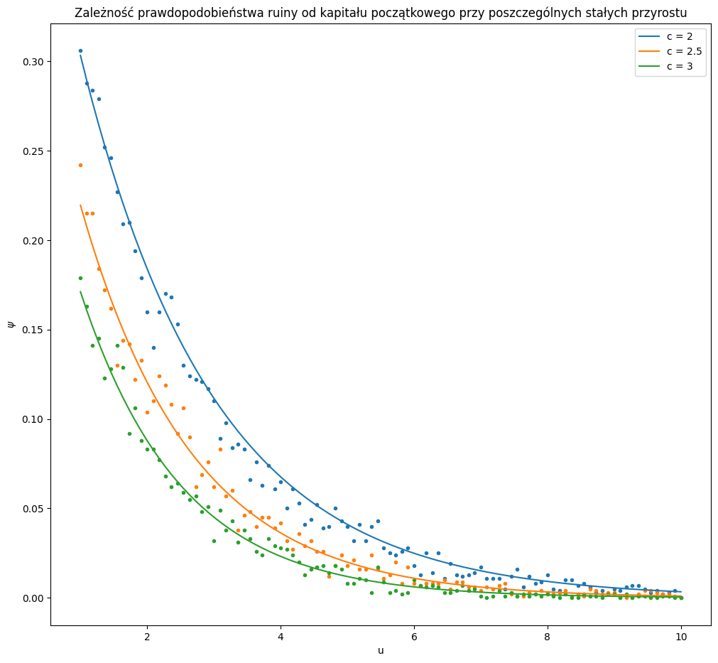

Widać tutaj, że dla konkretnych wartości premii $c$, prawdopodobieństwo ruiny jest tym mniejsze im większy jest kapitał początkowy $u$. Podobne zachowanie się prawdopodobieństwa zbadamy dla stałych kapitałów początkowych. Weźmiemu $u=\{4,6,8\}$ oraz $c$ będący 100-elementowych wektorem liczb z przedziału $[2,10]$.

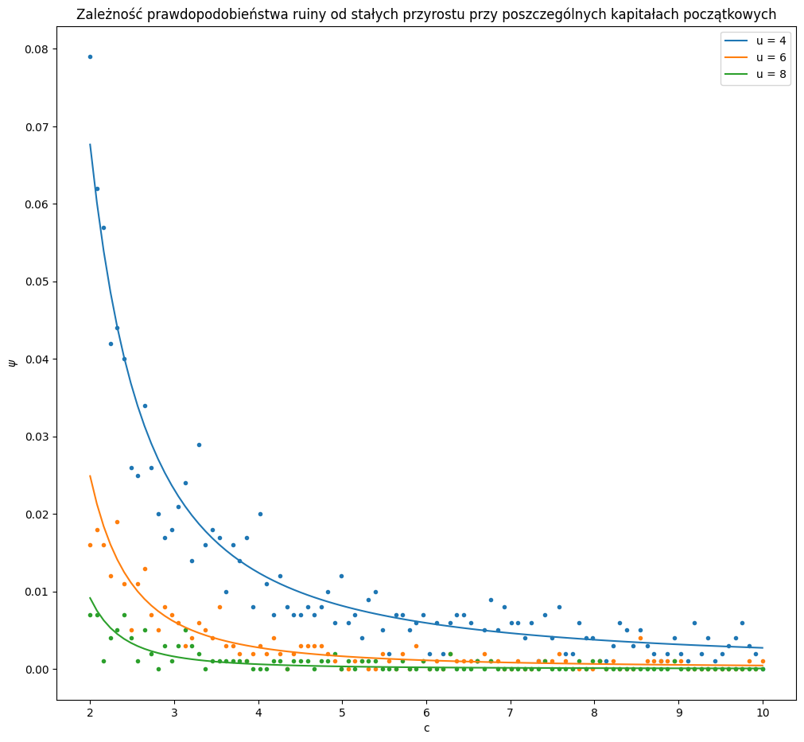

Można stąd łatwo zdobyć informacje jak dobrać $u$ i $c$ aby uzyskać dane prawdopodobieństwo ruiny.

Kolejnym krokiem naszej analizy będzie zastosowanie metod w celu wyznaczenia wartości $c$ przy danych kapitale początkowym i pradopodobieństwie ruiny. Wprowadzimy w tym celu funkcję odwrotną do wzoru Pollaczka-Chinczyna.

Będziemy chcieli przetestować jej działanie. W tym celu za jej pomocą wyznaczymy wartości $c$ dla pewnego $u$ oraz konkretnych $\psi$, które potem wstawimy do wzoru Pollaczka-Chinczyna, aby sprawdzić czy dadzą początkowe prawdopodobieństwa.

```
=======================================================================================
Testowa wartość psi: 0.1
Uzyskana wartość c z funkcji odwrotnej: 2.090710523553798
Wartości psi ze wzoru Pollaczka-Chinczyna dla uzyskanych c: 0.10000000000000002
=======================================================================================
Testowa wartość psi: 0.05
Uzyskana wartość c z funkcji odwrotnej: 2.851451304221464
Wartości psi ze wzoru Pollaczka-Chinczyna dla uzyskanych c: 0.04999999999999999
=======================================================================================
Testowa wartość psi: 0.025
Uzyskana wartość c z funkcji odwrotnej: 4.122818429760326
Wartości psi ze wzoru Pollaczka-Chinczyna dla uzyskanych c: 0.025
=======================================================================================
```

Jak widać otrzymaliśmy te same prawdopodobieństwa co na początku, co zapewnia nas o poprawnym działaniu funkcji. Następnie stworzymy funkcję która będzie wyliczała te same wartości $c$ empirycznie. Algorymt tego procesu jest bardzo złożony, dlatego wykorzystamy wiedzę o tym, że prawdopodobieństwo będzie malało im większe będzie $u$. Dlatego zaczniemy wykonywać symulację ruiny od większych do mniejszych $c$, aż prawdopodobieństwo symulacji nie będzie mniejsze od szukanego prawdopodobieństwa. Następnie zwiększamy $u$ i znowu sprawdzamy dla jakich kolejnych $c$ wartość prawdopodobieństwa ruiny będzie mniejsza od szukanej wartości.

Porównamy teraz obydwie metody i zobaczymy czy dają zgodne wyniki.

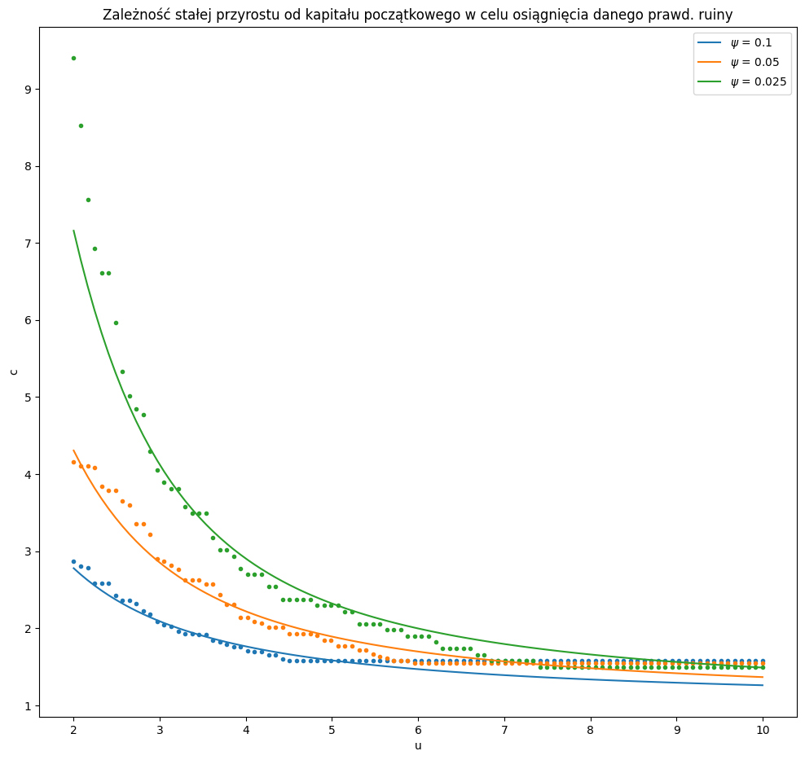

# Zadanie 6:

## Treść zadania

Ciągła zmienna losowa X ma rozkład arcusa sinusa (X ∼ Arcsine), gdy jej funkcja gęstości prawdopodobieństwa $p_X$ ma postać:

$$ p_X(x) = \frac{ 1 }{ \pi \sqrt{x(1 - x)} }\mathbb{1}_{(0, 1)}(x). $$

Dystrybuanta tej zmiennej jest wtedy równa

$$ F_X(x) = \begin{cases} 0, \ \ \ x \lt 0, \\ \frac{2}{\pi}\arcsin(\sqrt{x}), \ \ \ x \in [0, 1], \\ 1, \ \ \ x \gt 1. \end{cases} $$

Prawa arcusa sinusa dla procesu Wienera Wt brzmią następująco.

### Pierwsze prawo arcusa sinusa

$$ T_+ = \lambda ({ t \in [0, 1][W_t > 0] }) \sim \mathrm{Arcsine} $$

gdzie $\lambda$ to miara Lebesgue’a. Oznacza to, że czas spędzony przez proces Wienera powyżej osi OX na odcinku [0,1] ma rozkład arcusa sinusa.

### Drugie prawo arcusa sinusa

$$ L = \sup{ \{ t \in [0, 1][W_t = 0] \} } \sim \mathrm{Arcsine} $$

Inaczej mówiąc, ostatni moment uderzenia procesu Wienera na odcinku [0,1] w oś OX ma rozkład arcusa sinusa.

### Trzecie prawo arcusa sinusa

$$ W_M = \sup{ \{ W_t | t \in [0, 1] \} } \sim \mathrm{Arcsine}. $$

Oznacza to, że moment osiągnięcia maksymalnej wartości przez proces Wienera na odcinku [0,1] ma rozkład arcusa sinusa.

Zweryfikuj symulacyjnie prawa arcusa sinusa dla procesu Wienera. W tym celu użyj porównania histogramów oraz dystrybuant empirycznych wysymulowanych próbek z teoretycznymi wartościami.

## Rozwiązanie

Ciągła zmienna losowa X ma rozkład arcusa sinusa (X ∼ Arcsine), gdy jej funkcja gęstości prawdopodobieństwa $p_X$ ma postać:

$$ p_X(x) = \frac{ 1 }{ \pi \sqrt{x(1 - x)} }\mathbb{1}_{(0, 1)}(x). $$

Dystrybuanta tej zmiennej jest wtedy równa

$$ F_X(x) = \begin{cases} 0, \ \ \ x \lt 0, \\ \frac{2}{\pi}\arcsin(\sqrt{x}), \ \ \ x \in [0, 1], \\ 1, \ \ \ x \gt 1. \end{cases} $$

Zaimplementujemy ten rozkład jako klasę:

### Proces Wieniera $W_t$

Kolejnym istotnym zagadnieniem dla realizacji tego zadania jest proces Wieniera $W_t$. Scharakteryzowany jest on przez następujące ważne dla nas [własności](https://en.wikipedia.org/wiki/Wiener_process):

- $W_0 = 0$,
- $W_{t + u} - W_t ~ N(0, \mu)$

Zgodnie z tymi założeniami zaimplementujmy go

### Weryfikacja praw arcusa sinusa

#### Pierwsze prawo arcusa sinusa

$$ T_+ = \lambda ({ t \in [0, 1][W_t > 0] }) \sim \mathrm{Arcsine} $$

gdzie $\lambda$ to miara Lebesgue’a. Oznacza to, że czas spędzony przez proces Wienera powyżej osi OX na odcinku [0,1] ma rozkład arcusa sinusa.

Rozpoczniemy od implementacji funkcji, która pozwoli nam wyliczyć $T_+$

Chcąc dokonać weryfikacji podanego prawa rozpoczniemy od określenia konfiguracji naszego zadania (te same parametry wykorzystamy również dla weryfikacji późniejszych praw).

Posiadając tak przygotowane zaplecze kodowe możemy z użyciem metody Monte Carlo sprawdzić pierwsze prawo arcusa sinusa.

Tak posiadane dane możemy porównać wygodnie na wykresie wraz z rozkładem arcusa sinusa

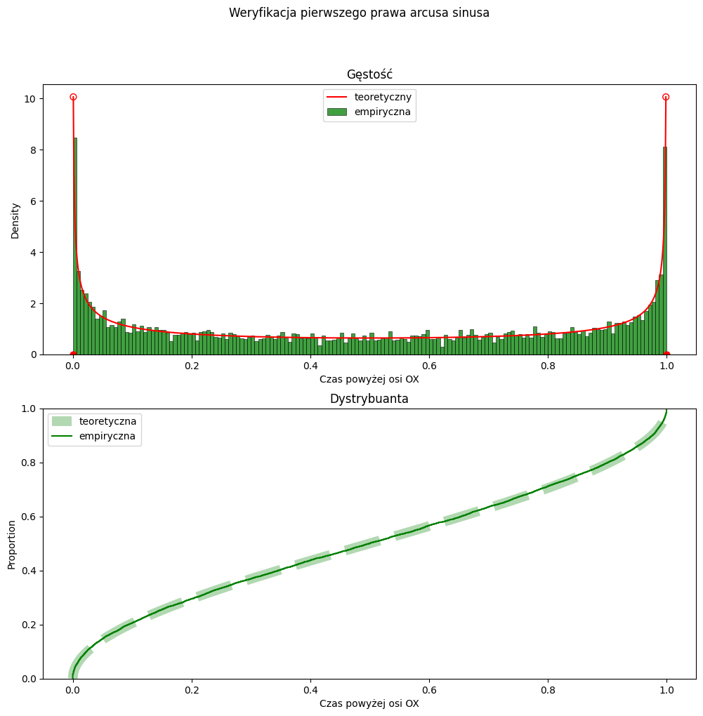

Na wykresie zaprezentowano

- dla gęstości: czerwoną linią wartości teoretyczne - zielonymi słupkami wartości histogramu empiryczne,
- dla dystrybuanty: zieloną linią przerywaną wartości teoretyczne - zieloną ciągłą linią natomiast wartości empiryczne.

Wykres jednoznacznie wskazuje, że próba losowa uzyskana zgodnie z pierwszym prawem arcsinusa jest z rozkładu Arcsine.

#### Drugie prawo arcusa sinusa

$$ L = \sup{ \{ t \in [0, 1][W_t = 0] \} } \sim \mathrm{Arcsine} $$

Inaczej mówiąc, ostatni moment uderzenia procesu Wienera na odcinku [0,1] w oś OX ma rozkład arcusa sinusa.

Rozpoczniemy od implementacji funkcji, która pozwoli nam wyliczyć $L$

Ponieważ generowany przez nas proces Wieniera jest dyskretyzowany przez czas, zamiast sprawdzać czy nasza sprawdzana wartość $W_t = 0$, sprawdzamy czy wartości $W_t$ i $W_{t - 1}$ mają różne znaki. Jeśli tak to w symulacji procesu ciągłego Wieniera wiemy z twierdzenia Darboux, że odbył się moment uderzenia procesu Wieniera w oś OX. W tej implementacji zakładamy, że ten moment to $\frac{t_n + t_{n-1}}{2}$, natomiast przyjęty może zostać dowolny punkt $\in [t_{n - 1}, t_n]$ zgodnie z podanym twierdzeniem Darboux. Dla dostatecznie dużej dyskretyzacji czasu dobór punktu z tego przedziału nie pownien mieć znaczenia.

Posiadając tak przygotowane zaplecze kodowe możemy z użyciem metody Monte Carlo sprawdzić drugie prawo arcusa sinusa.

Tak posiadane dane możemy porównać wygodnie na wykresie wraz z rozkładem arcusa sinusa

[figure not shown]

Na wykresie zaprezentowano

- dla gęstości: czerwoną linią wartości teoretyczne - zielonymi słupkami wartości histogramu empiryczne,
- dla dystrybuanty: zieloną linią przerywaną wartości teoretyczne - zieloną ciągłą linią natomiast wartości empiryczne.

Wykres jednoznacznie wskazuje, że próba losowa uzyskana zgodnie z drugim prawem arcsinusa jest z rozkładu Arcsine.